# Prediction of Business Success/Failure From Business Regional Characteristics (Supervised Learning)

I have downloaded the dataset from Kaggle.com, a platform for predictive modelling and analytics competitions which stores open source datasets uploaded by companies or users (Kaggle, 2018).

```python
# Import packages

import matplotlib.pyplot as plt
import pandas as pd
from datetime import datetime
import numpy as np
import seaborn as sns
import pysal as ps
from sklearn import cluster, metrics
from sklearn import preprocessing
from sklearn import model_selection
from sklearn.decomposition import PCA
from sklearn.preprocessing import scale
from sklearn.ensemble import RandomForestRegressor
from sklearn.linear_model import LinearRegression
import statsmodels.formula.api as sm
import statsmodels.api as sm
from collections import Counter
import collections
import itertools
from string import ascii_letters
from nltk.tokenize import word_tokenize
from nltk.corpus import stopwords
from nltk.stem import PorterStemmer
from wordcloud import WordCloud
from math import log, sqrt
from sklearn.model_selection import train_test_split
import json
from pandas.io.json import json_normalize
import ast
import altair as alt
from sklearn.linear_model import LogisticRegression

%matplotlib inline
```

```python
# read business data
business_data = pd.read_csv('./business_census2017.csv')
```

```python
# copy data
bus_data = business_data
```

```python
# explore dataset
bus_data.head(3)
```

|  | id | companynumber | countryoforigin | dissolutiondate | incorporationdate | accountingrefday | accountingrefmonth | account_nextduedate | account_lastmadeupdate | accountscategory | ... | nummortcharges | nummortoutstanding | nummortpartsatisfied | nummortsatisfied | siccode | sicdescription | return_nextduedate | return_lastmadeupdate | confirmation_nextduedate | confirmation_lastmadeupdate |
| --- | --- | --- | --- | --- | --- | --- | --- | --- | --- | --- | --- | --- | --- | --- | --- | --- | --- | --- | --- | --- | --- |
| 0 | 1 | 07382019 | UNITED KINGDOM | 2018-03-01 | 2010-09-21 | 30.0 | 9.0 | 2017-06-30 | 2015-09-30 | DORMANT | ... | 0.0 | 0.0 | 0.0 | 0.0 | 74100.0 | specialised design activities | 2016-10-19 | 2015-09-21 | 2017-10-05 | 2016-09-21 |
| 1 | 2 | 04753368 | UNITED KINGDOM | 2017-04-01 | 2003-05-03 | 30.0 | 4.0 | 2017-01-31 | 2014-10-31 | TOTAL EXEMPTION FULL | ... | 0.0 | 0.0 | 0.0 | 0.0 | 82990.0 | Other business support service activities n.e.c. | 2017-05-31 | 2016-05-03 | 2018-05-17 | NaN |
| 2 | 3 | SC421617 | UNITED KINGDOM | NaN | 2012-04-11 | 30.0 | 3.0 | 2017-12-30 | 2016-03-30 | TOTAL EXEMPTION SMALL | ... | 0.0 | 0.0 | 0.0 | 0.0 | 70229.0 | Management consultancy activities other than f... | 2017-05-09 | 2016-04-11 | 2018-04-25 | NaN |

3 rows × 33 columns

```python
# explore variables
bus_data.info()
```

```
<class 'pandas.core.frame.DataFrame'>
RangeIndex: 4077038 entries, 0 to 4077037
Data columns (total 33 columns):
id                             int64
companynumber                  object
countryoforigin                object
dissolutiondate                object
incorporationdate              object
accountingrefday               float64
accountingrefmonth             float64
account_nextduedate            object
account_lastmadeupdate         object
accountscategory               object
careof                         object
pobox                          object
addressline1                   object
addressline2                   object
posttown                       object
county                         object
country                        object
postcode                       object
companycategory                object
companyname                    object
numgenpartners                 float64
numlimpartners                 float64
companystatus                  object
nummortcharges                 float64
nummortoutstanding             float64
nummortpartsatisfied           float64
nummortsatisfied               float64
siccode                        float64
sicdescription                 object
return_nextduedate             object
return_lastmadeupdate          object
confirmation_nextduedate       object
confirmation_lastmadeupdate    object
dtypes: float64(9), int64(1), object(23)
memory usage: 1.0+ GB
```

```python
# how many observations and how many variables?
bus_data.shape
```

```
(4077038, 33)
```

### Data Pre-Processing

```python
# subset data to keep only variables of interest
bus_data = bus_data.iloc[:, [1,2,3,4,14,17,18,19,22,23,24,25,26,27]]
```

```python
# check variables left
bus_data.info()
```

```
<class 'pandas.core.frame.DataFrame'>
RangeIndex: 4077038 entries, 0 to 4077037
Data columns (total 14 columns):
companynumber           object
countryoforigin         object
dissolutiondate         object
incorporationdate       object
posttown                object
postcode                object
companycategory         object
companyname             object
companystatus           object
nummortcharges          float64
nummortoutstanding      float64
nummortpartsatisfied    float64
nummortsatisfied        float64
siccode                 float64
dtypes: float64(5), object(9)
memory usage: 435.5+ MB
```

#### Filter data set to include tech companies opened withing the last 15 years

```python
# keep only tech companies in the dataset by filtering through SIC Code
sic_codes = [62020, 62012, 62090]
data_tech = bus_data.loc[bus_data['siccode'].isin(sic_codes)]
```

#### SIC codes I am keeing

62020 = Information technology consultancy activities

62012 = Business and domestic software development

62090 = Other information technology service activities

```python
data_tech.shape
```

```
(208455, 14)
```

```python
# select all companies opened within the last 15 years.

# convert date columns to date
columns = ['dissolutiondate', 'incorporationdate']

for col in columns:
    data_tech[col] = pd.to_datetime(data_tech[col], format='%Y-%m-%d')

# select all companies opened after jan first 2002
data_tech_15 = data_tech.loc[data_tech['incorporationdate'] >= '2002-01-01']
```

```python
# make city lower case
data_tech_15['posttown'] = data_tech_15['posttown'].str.lower()
```

```python
# reset index
data_tech_15 = data_tech_15.reset_index(drop=True)
```

```python
data_tech_15.head()
```

|  | companynumber | countryoforigin | dissolutiondate | incorporationdate | posttown | postcode | companycategory | companyname | companystatus | nummortcharges | nummortoutstanding | nummortpartsatisfied | nummortsatisfied | siccode |
| --- | --- | --- | --- | --- | --- | --- | --- | --- | --- | --- | --- | --- | --- | --- |
| 0 | SC394469 | UNITED KINGDOM | NaT | 2011-03-01 | aberdeen | AB25 2QT | Private Limited Company | 'RIMS ENTERPRISE SOLUTIONS LTD | Active | 0.0 | 0.0 | 0.0 | 0.0 | 62090.0 |
| 1 | 06134719 | UNITED KINGDOM | 2018-01-01 | 2007-03-02 | london | EC2A 4NE | Private Limited Company | (BRACKET) DESIGN LTD. | Active | 0.0 | 0.0 | 0.0 | 0.0 | 62020.0 |
| 2 | 07649435 | UNITED KINGDOM | NaT | 2011-05-26 | london | EC4N 6NP | Private Limited Company | JUJU MEDIA LIMITED | Active | 0.0 | 0.0 | 0.0 | 0.0 | 62090.0 |
| 3 | 06534666 | UNITED KINGDOM | NaT | 2008-03-14 | bristol | BS1 2NT | Private Limited Company | (MID) DOTCOM LIMITED | Active | 0.0 | 0.0 | 0.0 | 0.0 | 62020.0 |
| 4 | 05153997 | UNITED KINGDOM | NaT | 2004-06-15 | bracknell | RG12 1QS | Private Limited Company | *+ LTD | Active | 0.0 | 0.0 | 0.0 | 0.0 | 62090.0 |

### Create new variables

- **Company Life**

```python
# subtrach dissolution date and incorporation date to see how many days the company has been open
data_tech_15['companylife'] = data_tech_15['dissolutiondate'] - data_tech_15['incorporationdate']
```

```python
# delete 'days' from column
data_tech_15['companylife'] = data_tech_15['companylife'].astype(str)
data_tech_15['companylife'] = data_tech_15['companylife'].map(lambda x: str(x)[:-24])

# make column float
data_tech_15['companylife'] = pd.to_numeric(data_tech_15['companylife'], errors='coerce')

# divide value by 365 to get year value

data_tech_15['companylife'] = data_tech_15['companylife'] / 365
```

```python
data_tech_15.head(2)
```

|  | companynumber | countryoforigin | dissolutiondate | incorporationdate | posttown | postcode | companycategory | companyname | companystatus | nummortcharges | nummortoutstanding | nummortpartsatisfied | nummortsatisfied | siccode | companylife |
| --- | --- | --- | --- | --- | --- | --- | --- | --- | --- | --- | --- | --- | --- | --- | --- |
| 0 | SC394469 | UNITED KINGDOM | NaT | 2011-03-01 | aberdeen | AB25 2QT | Private Limited Company | 'RIMS ENTERPRISE SOLUTIONS LTD | Active | 0.0 | 0.0 | 0.0 | 0.0 | 62090.0 | NaN |
| 1 | 06134719 | UNITED KINGDOM | 2018-01-01 | 2007-03-02 | london | EC2A 4NE | Private Limited Company | (BRACKET) DESIGN LTD. | Active | 0.0 | 0.0 | 0.0 | 0.0 | 62020.0 | 10.843836 |

- **Closed** = this is a binary variable

  closed = 0 company is still open  
  closed = 1 company is closed

This will be used as the response variable for machine learning

```python
%%time
#create a function that will assign 0 to all variables unless the company is closed
def closed(row):
    value = 0
    if row['companylife'] > 0:
        value = 1
    return value

data_tech_15['closed'] = data_tech_15.apply(closed, axis=1)
```

```
CPU times: user 19.5 s, sys: 480 ms, total: 20 s
Wall time: 24.7 s
```

## Data Exploration

- How many companies are still open, and how many are closed?

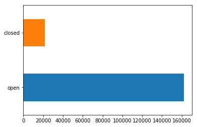

```python
closed = data_tech_15['closed'].value_counts()

# rename the axis so that they show in the picture
closed = closed.rename({0: 'open', 1: 'closed'})
# plot graph

closed.plot.barh();
```

- what is the percentage of open companies and closed companies?

```python
percentage = closed[1] / (closed[0] + closed[1])

print ('The % of closed comapnies in the dataset is: ' + str(percentage *100)+ ' %')
```

```
The % of closed comapnies in the dataset is: 11.763522258839908 %
```

- Are companies founded in specific more likely to be closed?

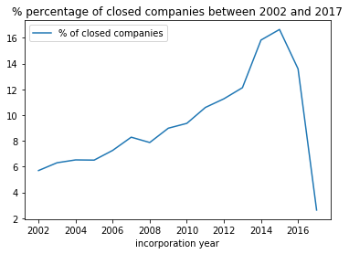

```python
# create column containing year only
data_tech_15['year'] = data_tech_15['incorporationdate'].dt.year

# create list with unique years
years = sorted((data_tech_15['year'].unique()) , key= int)

# create empty list
percentage_closed = []

# for each year
for i in years:
    # filter data by year
    datasplit = data_tech_15[data_tech_15['year'] == i]
    # count frequency of closed and open companies by year
    freq = datasplit['closed'].value_counts()
    closed = freq[1]
    opened = freq[0]
    # calculate the percentage of closed companies
    percentage = (closed / (opened + closed))*100
    # append percentages on empty list
    percentage_closed.append(percentage)

# create a dataframe containing years and percentage of closed companies for that year
percentage_cl = pd.DataFrame({
    'incorporation year': years,
    '% of closed companies': percentage_closed
    })

# Plot the data
percentage_cl.plot.line(x = 'incorporation year', y = '% of closed companies', title = '% percentage of closed companies between 2002 and 2017')
```

- What are the country of origins of the companies?

```python
# get unique country of origin values
origin = data_tech_15['countryoforigin'].value_counts()
```

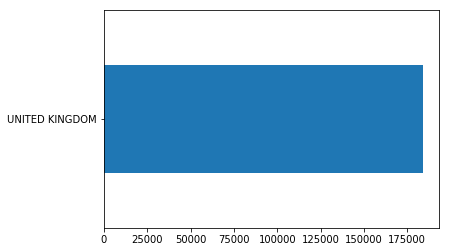

```python
origin.plot.barh()
```

All companies are from the United Kingdom

- What type of companies?

```python
typ = data_tech_15['companycategory'].value_counts()
typ
```

```
Private Limited Company                                                                      183428
PRI/LTD BY GUAR/NSC (Private, limited by guarantee, no share capital)                           188
Community Interest Company                                                                      102
PRI/LBG/NSC (Private, Limited by guarantee, no share capital, use of 'Limited' exemption)        87
Public Limited Company                                                                           65
Private Unlimited Company                                                                        11
Private Unlimited                                                                                 1
Name: companycategory, dtype: int64
```

```python
# semplify the categories
privat = ['Private Limited Company','PRI/LTD BY GUAR/NSC (Private, limited by guarantee, no share capital)',
         "PRI/LBG/NSC (Private, Limited by guarantee, no share capital, use of 'Limited' exemption)",
         'Private Unlimited Company','Private Unlimited']

for i in privat:
    data_tech_15['companycategory']=np.where(data_tech_15['companycategory'] == i, 'Private',data_tech_15['companycategory'] )
```

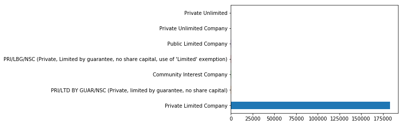

```python
typ.plot.barh()
```

Most companies are Private Limited Companies.

Let's look at of open and closed companies are distributed similarly.

```python
closed_type = data_tech_15[data_tech_15['closed']==1]
closed_count = closed_type['companycategory'].value_counts()

closed_count
```

```
Private                       21608
Community Interest Company       18
Public Limited Company            5
Name: companycategory, dtype: int64
```

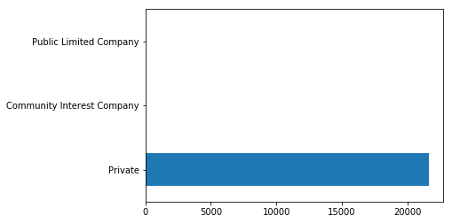

```python
closed_count.plot.barh()
```

```python
open_type = data_tech_15[data_tech_15['closed']==0]
open_count = open_type['companycategory'].value_counts()

open_count
```

```
Private                       162107
Community Interest Company        84
Public Limited Company            60
Name: companycategory, dtype: int64
```

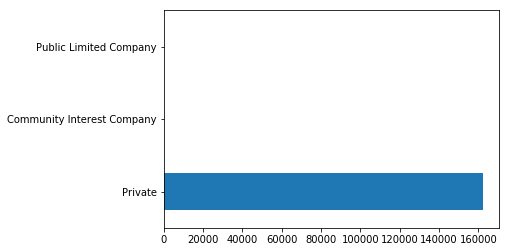

```python
open_count.plot.barh()
```

## Data Linkage

- At this point I am attaching regiona characteristics to my datasets
- this information is taken from the 2011 census.
- **Postcode** Data

```python
# read data
postcodes = pd.read_csv('./postcodes.csv')
```

```python
# make a copy of the dataset
pcodes = postcodes
# selevt variables of interest (postcode and wardcode)
pcodes = pcodes.iloc[:,[2,6]]
# rename columns
pcodes = pcodes.rename(index=str, columns={"pcds": "postcode", "wd11cd": "ward_code"})
pcodes.head()
```

|  | postcode | ward_code |
| --- | --- | --- |
| 0 | AL1 1AG | E05004802 |
| 1 | AL1 1AJ | E05004802 |
| 2 | AL1 1AR | E05004789 |
| 3 | AL1 1AS | E05004799 |
| 4 | AL1 1BH | E05004802 |

- **Qualifications** Data

Qualifications Qualifications metadata taken from UK Data Service website.

- No Qualifications: No academic or professional qualifications. +Level 1 qualifications: 1-4 O Levels/CSE/GCSEs (any grades), Entry Level, Foundation Diploma, NVQ level 1, Foundation GNVQ, Basic/Essential Skills.
- Level 2 qualifications: 5+ O Level (Passes)/CSEs (Grade 1)/GCSEs (Grades A*-C), School Certificate, 1 A Level/ 2-3 AS Levels/VCEs, Intermediate/Higher Diploma, Welsh Baccalaureate Intermediate Diploma, NVQ level 2, Intermediate GNVQ, City and Guilds Craft, BTEC First/General Diploma, RSA Diploma Apprenticeship.
- Level 3 qualifications: 2+ A Levels/VCEs, 4+ AS Levels, Higher School Certificate, Progression/Advanced Diploma, Welsh Baccalaureate Advanced Diploma, NVQ Level 3; Advanced GNVQ, City and Guilds Advanced Craft, ONC, OND, BTEC National, RSA Advanced Diploma.
- Level 4+ qualifications: Degree (for example BA, BSc), Higher Degree (for example MA, PhD, PGCE), NVQ Level 4-5, HNC, HND, RSA Higher Diploma, BTEC Higher level, Foundation degree (NI), Professional qualifications (for example teaching, nursing, accountancy).
- Other qualifications: Vocational/Work-related Qualifications, Foreign Qualifications (Not stated/ level unknown).

```python
# read data
qualifications = pd.read_csv('./qualifications.csv')
```

```python
# copy dataset
qualif = qualifications

# subset
qualif = qualif.iloc[:, [1,9]]

# remane
qualif = qualif.rename(index=str, columns={"GEO_CODE": "ward_code", "F192": "Economically Active - level_4 qualification"})

# delete first row
qualif = qualif.iloc[1:]

qualif.head()
```

|  | ward_code | Economically Active - level_4 qualification |
| --- | --- | --- |
| 1 | 95AA01 | 977 |
| 2 | 95AA02 | 230 |
| 3 | 95AA03 | 167 |
| 4 | 95AA04 | 634 |
| 5 | 95AA05 | 546 |

- **Population Density** Data

```python
# read data
population = pd.read_csv('./residents.csv')
```

```python
# copy data
pop = population
```

```python
pop = pop.iloc[:, [1,5]]
pop = pop.iloc[1:]
pop = pop.rename(index=str, columns={"GEO_CODE": "ward_code", "F2384": "population density"})
pop.head()
```

|  | ward_code | population density |
| --- | --- | --- |
| 1 | 95AA01 | 4444 |
| 2 | 95AA02 | 1734 |
| 3 | 95AA03 | 1822 |
| 4 | 95AA04 | 3013 |
| 5 | 95AA05 | 2701 |

- **Unemployment** Data

**Economic activity** relates to whether or not a person who was aged 16 and over was working or looking for work in the week before census. Rather than a simple indicator of whether or not someone was currently in employment, it provides a measure of whether or not a person was an active participant in the labour market. A person’s economic activity is derived from their ‘activity last week’. This is an indicator of their status or availability for employment - whether employed, unemployed, or their status if not employed and not seeking employment. Additional information included in the economic activity classification is also derived from information about the number of hours a person works and their type of employment - whether employed or self-employed. The census concept of economic activity is compatible with the standard for economic status defined by the International Labour Organisation (ILO). It is one of a number of definitions used internationally to produce accurate and comparable statistics on employment, unemployment and economic status.

```python
# read data
unemployment = pd.read_csv('./unemploy.csv')
```

```python
# copy data
unemploy = unemployment
```

```python
unemploy = unemploy.iloc[:, [1,5,6]]
unemploy = unemploy.iloc[1:]
unemploy = unemploy.rename(index=str, columns={"GEO_CODE": "ward_code",
                                     "F244": "Economically Active",
                                     'F248': 'Economically Active - Unemployed'})
unemploy.head()
```

|  | ward_code | Economically Active | Economically Active - Unemployed |
| --- | --- | --- | --- |
| 1 | 95AA01 | 2473 | 107 |
| 2 | 95AA02 | 892 | 57 |
| 3 | 95AA03 | 840 | 57 |
| 4 | 95AA04 | 1660 | 72 |
| 5 | 95AA05 | 1362 | 77 |

- **Universities** Data

```python
# read data
universities = pd.read_csv('./Harris.csv')
```

```python
# copy
uni = universities
```

```python
uni = uni.iloc[:, [4,6,13,15]]
uni = uni.rename(index=str, columns={"Unnamed: 4": "University Name",
                                     'Unnamed: 6': 'University type group',
                                     'Unnamed: 13': 'posttown',
                                     'Unnamed: 15': 'postcode'})
uni = uni.iloc[1:]


uni.head()
```

|  | University Name | University type group | posttown | postcode |
| --- | --- | --- | --- | --- |
| 1 | Sir John Cass's Foundation Primary School | LA maintained schools | London | EC3A 5DE |
| 2 | City of London School for Girls | Independent schools | London | EC2Y 8BB |
| 3 | St Paul's Cathedral School | Independent schools | London | EC4M 9AD |
| 4 | City of London School | Independent schools | London | EC4V 3AL |
| 5 | The Charterhouse Square School | Independent schools | London | EC1M 6EA |

```python
# check the value of type group.
uni['University type group'].unique()
```

```
array(['LA maintained schools', 'Independent schools', 'Universities',
       'Free Schools', 'Academies', 'Colleges', 'Special schools',
       'Other types'], dtype=object)
```

```python
uni.head()
```

|  | University Name | University type group | posttown | postcode |
| --- | --- | --- | --- | --- |
| 1 | Sir John Cass's Foundation Primary School | LA maintained schools | London | EC3A 5DE |
| 2 | City of London School for Girls | Independent schools | London | EC2Y 8BB |
| 3 | St Paul's Cathedral School | Independent schools | London | EC4M 9AD |
| 4 | City of London School | Independent schools | London | EC4V 3AL |
| 5 | The Charterhouse Square School | Independent schools | London | EC1M 6EA |

```python
# filter for universities
uni['University type group'].unique()
```

```
array(['LA maintained schools', 'Independent schools', 'Universities',
       'Free Schools', 'Academies', 'Colleges', 'Special schools',
       'Other types'], dtype=object)
```

```python
# filter universities
uni = uni.loc[uni['University type group']== 'Universities']
```

```python
# make posttown lowercase
uni['posttown'] = uni['posttown'].str.lower()
uni = uni.reset_index(drop = True)
```

```python
uni.head()
```

|  | University Name | University type group | posttown | postcode |
| --- | --- | --- | --- | --- |
| 0 | London Metropolitan University | Universities | london | N7 8DB |
| 1 | Guildhall School of Music and Drama | Universities | london | EC2Y 8DT |
| 2 | The Royal Veterinary College | Universities | london | NW1 0TU |
| 3 | Central School of Speech and Drama | Universities | london | NW3 3HY |
| 4 | University College London | Universities | london | WC1E 6BT |

## Link Datasets

```python
# recall business dataset
data_tech_15.head()
```

|  | companynumber | countryoforigin | dissolutiondate | incorporationdate | posttown | postcode | companycategory | companyname | companystatus | nummortcharges | nummortoutstanding | nummortpartsatisfied | nummortsatisfied | siccode | companylife | closed | year |
| --- | --- | --- | --- | --- | --- | --- | --- | --- | --- | --- | --- | --- | --- | --- | --- | --- | --- |
| 0 | SC394469 | UNITED KINGDOM | NaT | 2011-03-01 | aberdeen | AB25 2QT | Private | 'RIMS ENTERPRISE SOLUTIONS LTD | Active | 0.0 | 0.0 | 0.0 | 0.0 | 62090.0 | NaN | 0 | 2011 |
| 1 | 06134719 | UNITED KINGDOM | 2018-01-01 | 2007-03-02 | london | EC2A 4NE | Private | (BRACKET) DESIGN LTD. | Active | 0.0 | 0.0 | 0.0 | 0.0 | 62020.0 | 10.843836 | 1 | 2007 |
| 2 | 07649435 | UNITED KINGDOM | NaT | 2011-05-26 | london | EC4N 6NP | Private | JUJU MEDIA LIMITED | Active | 0.0 | 0.0 | 0.0 | 0.0 | 62090.0 | NaN | 0 | 2011 |
| 3 | 06534666 | UNITED KINGDOM | NaT | 2008-03-14 | bristol | BS1 2NT | Private | (MID) DOTCOM LIMITED | Active | 0.0 | 0.0 | 0.0 | 0.0 | 62020.0 | NaN | 0 | 2008 |
| 4 | 05153997 | UNITED KINGDOM | NaT | 2004-06-15 | bracknell | RG12 1QS | Private | *+ LTD | Active | 0.0 | 0.0 | 0.0 | 0.0 | 62090.0 | NaN | 0 | 2004 |

```python
# delete more columns
data_tech_15 = data_tech_15.iloc[:, [2,3,4,5,6,9,10,11,12,15]]
data_tech_15.head()
```

|  | dissolutiondate | incorporationdate | posttown | postcode | companycategory | nummortcharges | nummortoutstanding | nummortpartsatisfied | nummortsatisfied | closed |
| --- | --- | --- | --- | --- | --- | --- | --- | --- | --- | --- |
| 0 | NaT | 2011-03-01 | aberdeen | AB25 2QT | Private | 0.0 | 0.0 | 0.0 | 0.0 | 0 |
| 1 | 2018-01-01 | 2007-03-02 | london | EC2A 4NE | Private | 0.0 | 0.0 | 0.0 | 0.0 | 1 |
| 2 | NaT | 2011-05-26 | london | EC4N 6NP | Private | 0.0 | 0.0 | 0.0 | 0.0 | 0 |
| 3 | NaT | 2008-03-14 | bristol | BS1 2NT | Private | 0.0 | 0.0 | 0.0 | 0.0 | 0 |
| 4 | NaT | 2004-06-15 | bracknell | RG12 1QS | Private | 0.0 | 0.0 | 0.0 | 0.0 | 0 |

```python
# merge postcode dataset to get ward code
merge1 = pd.merge(data_tech_15, pcodes, on='postcode', how='inner')
merge2 = pd.merge(merge1, pop, on='ward_code', how='left')
merge3 = pd.merge(merge2, qualif, on='ward_code', how='left')
merge4 = pd.merge(merge3, unemploy, on='ward_code', how='left')
```

```python
merge4.head()
```

|  | dissolutiondate | incorporationdate | posttown | postcode | companycategory | nummortcharges | nummortoutstanding | nummortpartsatisfied | nummortsatisfied | closed | ward_code | population density | Economically Active - level_4 qualification | Economically Active | Economically Active - Unemployed |
| --- | --- | --- | --- | --- | --- | --- | --- | --- | --- | --- | --- | --- | --- | --- | --- |
| 0 | 2018-01-01 | 2007-03-02 | london | EC2A 4NE | Private | 0.0 | 0.0 | 0.0 | 0.0 | 1 | E05000239 | 13904 | 5351 | 8294 | 736 |
| 1 | NaT | 2011-08-19 | london | EC2A 4NE | Private | 0.0 | 0.0 | 0.0 | 0.0 | 0 | E05000239 | 13904 | 5351 | 8294 | 736 |
| 2 | 2017-12-01 | 2008-10-29 | london | EC2A 4NE | Private | 0.0 | 0.0 | 0.0 | 0.0 | 1 | E05000239 | 13904 | 5351 | 8294 | 736 |
| 3 | NaT | 2007-04-11 | london | EC2A 4NE | Private | 0.0 | 0.0 | 0.0 | 0.0 | 0 | E05000239 | 13904 | 5351 | 8294 | 736 |
| 4 | NaT | 2010-07-09 | london | EC2A 4NE | Private | 0.0 | 0.0 | 0.0 | 0.0 | 0 | E05000239 | 13904 | 5351 | 8294 | 736 |

```python
# check type of variables
merge4.info()
```

```
<class 'pandas.core.frame.DataFrame'>
Int64Index: 129112 entries, 0 to 129111
Data columns (total 15 columns):
dissolutiondate                                14794 non-null datetime64[ns]
incorporationdate                              129112 non-null datetime64[ns]
posttown                                       128057 non-null object
postcode                                       129112 non-null object
companycategory                                129112 non-null object
nummortcharges                                 129112 non-null float64
nummortoutstanding                             129112 non-null float64
nummortpartsatisfied                           129112 non-null float64
nummortsatisfied                               129112 non-null float64
closed                                         129112 non-null int64
ward_code                                      129112 non-null object
population density                             128677 non-null object
Economically Active - level_4 qualification    128677 non-null object
Economically Active                            128677 non-null object
Economically Active - Unemployed               128677 non-null object
dtypes: datetime64[ns](2), float64(4), int64(1), object(8)
memory usage: 15.8+ MB
```

```python
# make last columns floats
cols = ['population density', 'Economically Active - level_4 qualification', 'Economically Active',\
        'Economically Active - Unemployed']
for col in cols:
    merge4[col] = merge4[col].astype(float)
```

```python
# create new variables
merge4['% economically active with level 4 qualification'] = merge4['Economically Active - level_4 qualification']/\
                                                            merge4['Economically Active']

merge4['% economically active'] = merge4['Economically Active']/\
                                  merge4['population density']
merge4['% economically active unemployed'] = merge4['Economically Active - Unemployed']/\
                                             merge4['Economically Active']
```

```python
# attach number of companies in the same town, and number of companies in the same ward
companies_in_ward = pd.DataFrame(merge4['ward_code'].value_counts())
companies_in_ward = companies_in_ward.reset_index(drop=False)
companies_in_ward = companies_in_ward.rename(index=str, columns={"index": "ward_code",
                                                                 'ward_code':'n. of companies in ward'})



companies_in_city = pd.DataFrame(merge4['posttown'].value_counts())
companies_in_city = companies_in_city.reset_index(drop=False)
companies_in_city = companies_in_city.rename(index=str, columns={"index": "posttown",
                                                                 'posttown':'n. of companies in city'})
```

```python
merge5 = pd.merge(merge4, companies_in_city, on='posttown', how='left')
merge6 = pd.merge(merge5, companies_in_ward, on='ward_code', how='left')
```

```python
merge6.head()
```

|  | dissolutiondate | incorporationdate | posttown | postcode | companycategory | nummortcharges | nummortoutstanding | nummortpartsatisfied | nummortsatisfied | closed | ward_code | population density | Economically Active - level_4 qualification | Economically Active | Economically Active - Unemployed | % economically active with level 4 qualification | % economically active | % economically active unemployed | n. of companies in city | n. of companies in ward |
| --- | --- | --- | --- | --- | --- | --- | --- | --- | --- | --- | --- | --- | --- | --- | --- | --- | --- | --- | --- | --- |
| 0 | 2018-01-01 | 2007-03-02 | london | EC2A 4NE | Private | 0.0 | 0.0 | 0.0 | 0.0 | 1 | E05000239 | 13904.0 | 5351.0 | 8294.0 | 736.0 | 0.645165 | 0.596519 | 0.088739 | 23260.0 | 639 |
| 1 | NaT | 2011-08-19 | london | EC2A 4NE | Private | 0.0 | 0.0 | 0.0 | 0.0 | 0 | E05000239 | 13904.0 | 5351.0 | 8294.0 | 736.0 | 0.645165 | 0.596519 | 0.088739 | 23260.0 | 639 |
| 2 | 2017-12-01 | 2008-10-29 | london | EC2A 4NE | Private | 0.0 | 0.0 | 0.0 | 0.0 | 1 | E05000239 | 13904.0 | 5351.0 | 8294.0 | 736.0 | 0.645165 | 0.596519 | 0.088739 | 23260.0 | 639 |
| 3 | NaT | 2007-04-11 | london | EC2A 4NE | Private | 0.0 | 0.0 | 0.0 | 0.0 | 0 | E05000239 | 13904.0 | 5351.0 | 8294.0 | 736.0 | 0.645165 | 0.596519 | 0.088739 | 23260.0 | 639 |
| 4 | NaT | 2010-07-09 | london | EC2A 4NE | Private | 0.0 | 0.0 | 0.0 | 0.0 | 0 | E05000239 | 13904.0 | 5351.0 | 8294.0 | 736.0 | 0.645165 | 0.596519 | 0.088739 | 23260.0 | 639 |

```python
# delete columns I won't use
merge6 = merge6.iloc[:, [0,1,2,3,4,5,6,7,8,9,11,15,16,17,18,19]]
```

```python
# add number of universities in the same city
universities_in_city = pd.DataFrame(uni['posttown'].value_counts())
universities_in_city = universities_in_city.reset_index(drop=False)
universities_in_city = universities_in_city.rename(index=str, columns={"index": "posttown",
                                                                 'posttown':'n. of universities in city'})

universities_in_city.head()
```

|  | posttown | n. of universities in city |
| --- | --- | --- |
| 0 | london | 37 |
| 1 | leeds | 6 |
| 2 | manchester | 5 |
| 3 | birmingham | 5 |
| 4 | liverpool | 4 |

```python
# merge with data
merge7 = pd.merge(merge6, universities_in_city, on='posttown', how='left')
```

```python
total = merge7
total = total.fillna(0)
total.head()
```

|  | dissolutiondate | incorporationdate | posttown | postcode | companycategory | nummortcharges | nummortoutstanding | nummortpartsatisfied | nummortsatisfied | closed | population density | % economically active with level 4 qualification | % economically active | % economically active unemployed | n. of companies in city | n. of companies in ward | n. of universities in city |
| --- | --- | --- | --- | --- | --- | --- | --- | --- | --- | --- | --- | --- | --- | --- | --- | --- | --- |
| 0 | 2018-01-01 00:00:00 | 2007-03-02 | london | EC2A 4NE | Private | 0.0 | 0.0 | 0.0 | 0.0 | 1 | 13904.0 | 0.645165 | 0.596519 | 0.088739 | 23260.0 | 639 | 37.0 |
| 1 | 0 | 2011-08-19 | london | EC2A 4NE | Private | 0.0 | 0.0 | 0.0 | 0.0 | 0 | 13904.0 | 0.645165 | 0.596519 | 0.088739 | 23260.0 | 639 | 37.0 |
| 2 | 2017-12-01 00:00:00 | 2008-10-29 | london | EC2A 4NE | Private | 0.0 | 0.0 | 0.0 | 0.0 | 1 | 13904.0 | 0.645165 | 0.596519 | 0.088739 | 23260.0 | 639 | 37.0 |
| 3 | 0 | 2007-04-11 | london | EC2A 4NE | Private | 0.0 | 0.0 | 0.0 | 0.0 | 0 | 13904.0 | 0.645165 | 0.596519 | 0.088739 | 23260.0 | 639 | 37.0 |
| 4 | 0 | 2010-07-09 | london | EC2A 4NE | Private | 0.0 | 0.0 | 0.0 | 0.0 | 0 | 13904.0 | 0.645165 | 0.596519 | 0.088739 | 23260.0 | 639 | 37.0 |

## More Data Visualisation

- I will first plot a pairplot to see the relationships among each pair of variables.

```python
# scatter plot
total_num = total.iloc[:,9:]
total_num = total_num.dropna()
total_num.head()
```

|  | closed | population density | % economically active with level 4 qualification | % economically active | % economically active unemployed | n. of companies in city | n. of companies in ward | n. of universities in city |
| --- | --- | --- | --- | --- | --- | --- | --- | --- |
| 0 | 1 | 13904.0 | 0.645165 | 0.596519 | 0.088739 | 23260.0 | 639 | 37.0 |
| 1 | 0 | 13904.0 | 0.645165 | 0.596519 | 0.088739 | 23260.0 | 639 | 37.0 |
| 2 | 1 | 13904.0 | 0.645165 | 0.596519 | 0.088739 | 23260.0 | 639 | 37.0 |
| 3 | 0 | 13904.0 | 0.645165 | 0.596519 | 0.088739 | 23260.0 | 639 | 37.0 |
| 4 | 0 | 13904.0 | 0.645165 | 0.596519 | 0.088739 | 23260.0 | 639 | 37.0 |

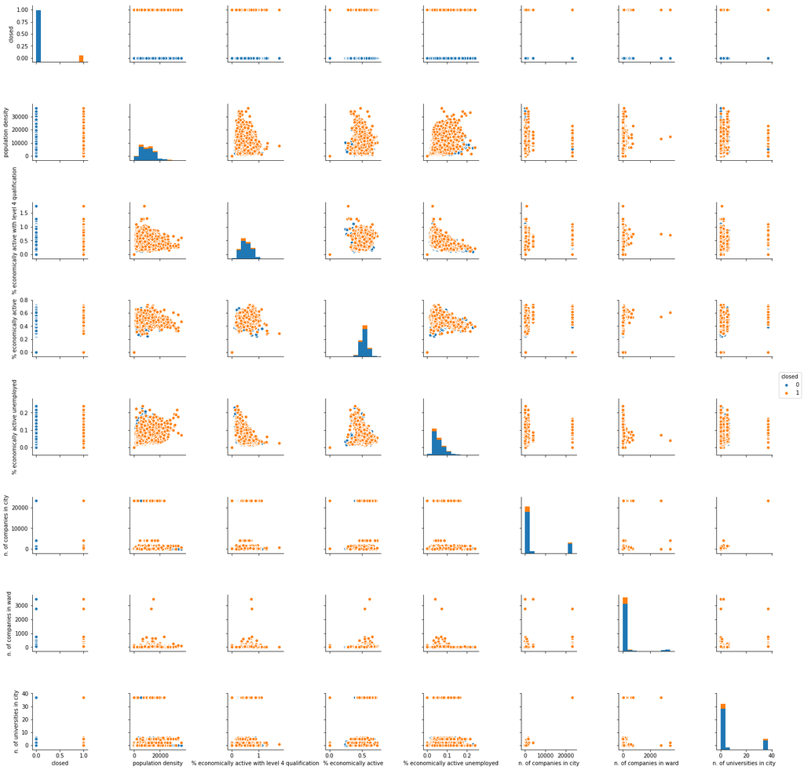

```python
sns.pairplot(total_num, kind='scatter', hue= 'closed');
```

- Next I will plot density plots to see the distribution of the variables for companies that are still open VS companies that are closed. this will allow me to see immediate differences in the distributions.

```python
#create a function that will code and uncode data
def code(row):
    value = 'closed'
    if row['closed'] == 0:
        value = 'open'
    return value

def code_reverse(row):
    value = 1
    if row['closed'] == 'open':
        value = 0
    return value
```

```python
%%time
total['closed'] = total.apply(code, axis = 1)
```

```
CPU times: user 12.7 s, sys: 270 ms, total: 12.9 s
Wall time: 14.7 s
```

```
Text(0,0.5,'Density')
```

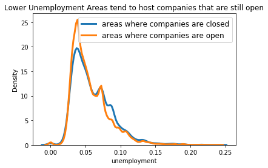

```python
# values for which to subset
closed= ['closed','open']

# Iterate through the dataset and subset for open and closed companies
for i in closed:
    subset = total[total['closed'] == i]

    # Draw the density plot
    sns.distplot(subset['% economically active unemployed'], hist = False, kde = True,
                 kde_kws = {'linewidth': 3},
                 label = 'areas where companies are '+i)

# Plot formatting
plt.legend(prop={'size': 12}, title = '')
plt.title('Lower Unemployment Areas tend to host companies that are still open')
plt.xlabel('unemployment')
plt.ylabel('Density')
```

**The plot shows that areas where companies are still open have a lower percentage of unemployement**

```
Text(0,0.5,'Density')
```

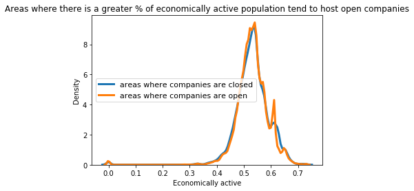

```python
# values for which to subset
closed= ['closed','open']

# Iterate through the dataset and subset for open and closed companies
for i in closed:
    subset = to_vis[to_vis['closed'] == i]

    # Draw the density plot
    sns.distplot(subset['% economically active'], hist = False, kde = True,
                 kde_kws = {'linewidth': 3},
                 label = 'areas where companies are '+i)

# Plot formatting
plt.legend(prop={'size': 11}, title = '')
plt.title('Areas where there is a greater % of economically active population tend to host open companies')
plt.xlabel('Economically active')
plt.ylabel('Density')
```

- **The distribution are very similar.**
- **The spike at around 0.6 shows that areas where companies are still open, also have a higher percentage of people that are economically active and therefore contribute to the workforce.

```
Text(0,0.5,'Density')
```

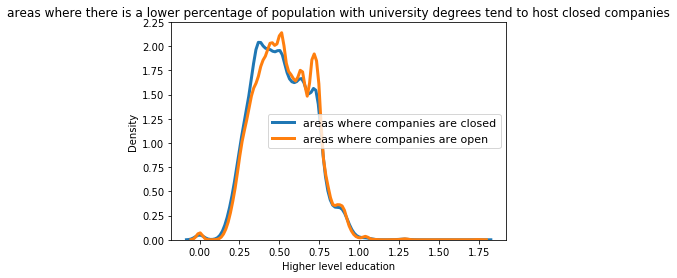

```python
# values for which to subset
closed= ['closed','open']

# Iterate through the dataset and subset for open and closed companies
for i in closed:
    subset = to_vis[to_vis['closed'] == i]

    # Draw the density plot
    sns.distplot(subset['% economically active with level 4 qualification'], hist = False, kde = True,
                 kde_kws = {'linewidth': 3},
                 label = 'areas where companies are '+i)

# Plot formatting
plt.legend(prop={'size': 11}, title = '')
plt.title('areas where there is a lower percentage of population with university degrees tend to host closed companies')
plt.xlabel('Higher level education')
plt.ylabel('Density')
```

- **The distribution shows that areas that have a lower percentage of people with a higher education degree are area where companies are currently closed (0.25).**
- **On the contrary,at areas where 75% of economically active population has a higher education degree, there is higher density of opened companies other than closed companies.**

## Machine Learning

### Logistic Regression

#### Step 1: scale data

I am going to scale data because the variables in the dataset are on different scales. For example, some are percentages, some are n. of morgases etc...

```python
# scale data frame
# columns to scale
toscale = ['nummortcharges', 'nummortoutstanding', \
'nummortpartsatisfied', 'nummortsatisfied', \
'population density','% economically active with level 4 qualification',\
'% economically active', '% economically active unemployed',\
'n. of companies in city', 'n. of companies in ward',\
'n. of universities in city']

#scale
scaled = pd.DataFrame(scale(total[toscale]),
                   index=total.index,
                   columns=toscale)
```

```python
# check that standard deviation is all the same
scaled.describe().head(3)
```

|  | nummortcharges | nummortoutstanding | nummortpartsatisfied | nummortsatisfied | population density | % economically active with level 4 qualification | % economically active | % economically active unemployed | n. of companies in city | n. of companies in ward | n. of universities in city |
| --- | --- | --- | --- | --- | --- | --- | --- | --- | --- | --- | --- |
| count | 1.291120e+05 | 1.291120e+05 | 1.291120e+05 | 1.291120e+05 | 1.291120e+05 | 1.291120e+05 | 1.291120e+05 | 1.291120e+05 | 1.291120e+05 | 1.291120e+05 | 1.291120e+05 |
| mean | 3.874327e-17 | 9.685817e-18 | -6.879131e-19 | 1.144687e-17 | -9.179513e-17 | 2.888135e-16 | 5.608969e-16 | -3.486894e-16 | 1.375826e-17 | -6.339808e-17 | 5.354716e-17 |
| std | 1.000004e+00 | 1.000004e+00 | 1.000004e+00 | 1.000004e+00 | 1.000004e+00 | 1.000004e+00 | 1.000004e+00 | 1.000004e+00 | 1.000004e+00 | 1.000004e+00 | 1.000004e+00 |

```python
# add variables to scaled dataset
scaled['closed'] = total['closed']
scaled['companycategory'] = total['companycategory']
```

```python
# create dummy variables
cat_vars=['companycategory']

for var in cat_vars:
    cat_list='var'+'_'+var
    cat_list = pd.get_dummies(scaled[var], prefix=var)
    data1=scaled.join(cat_list)
    data1 = data1.drop(var,1)
    scaled=data1

data_vars=scaled.columns.values.tolist()
to_keep=[i for i in data_vars if i not in cat_vars]
```

```python
# code variables back to 0 and 1 to run it into the regression function.
scaled['closed'] = scaled.apply(code_reverse, axis = 1)
```

#### Step 2: Implement model and see which variables are significant and which ones aren't

```python
cols = ['nummortcharges', 'nummortoutstanding', 'nummortpartsatisfied',
       'nummortsatisfied', 'population density',
       '% economically active with level 4 qualification',
       '% economically active', '% economically active unemployed',
       'n. of companies in city', 'n. of companies in ward',
       'n. of universities in city',
       'companycategory_Community Interest Company', 'companycategory_Private',
       'companycategory_Public Limited Company']

X = scaled[cols]
y = scaled['closed']

logit_model=sm.Logit(y,X.astype(float))
result=logit_model.fit()
result.summary2()
```

| Model: | Logit | No. Iterations: | 35.0000 |
| --- | --- | --- | --- |
| Dependent Variable: | closed | Pseudo R-squared: | 0.005 |
| Date: | 2018-09-25 18:25 | AIC: | 91489.1146 |
| No. Observations: | 129112 | BIC: | 91625.8727 |
| Df Model: | 13 | Log-Likelihood: | -45731. |
| Df Residuals: | 129098 | LL-Null: | -45963. |
| Converged: | 0.0000 | Scale: | 1.0000 |

|  | Coef. | Std.Err. | z | P>\|z\| | [0.025 | 0.975] |
| --- | --- | --- | --- | --- | --- | --- |
| nummortcharges | 0.6645 | 0.3749 | 1.7728 | 0.0763 | -0.0702 | 1.3992 |
| nummortoutstanding | -0.6325 | 0.2761 | -2.2908 | 0.0220 | -1.1736 | -0.0913 |
| nummortpartsatisfied | -0.0744 | 1485.9425 | -0.0001 | 1.0000 | -2912.4681 | 2912.3193 |
| nummortsatisfied | -0.3745 | 0.1952 | -1.9186 | 0.0550 | -0.7570 | 0.0081 |
| population density | -0.0274 | 0.0110 | -2.4858 | 0.0129 | -0.0489 | -0.0058 |
| % economically active with level 4 qualification | -0.0528 | 0.0116 | -4.5402 | 0.0000 | -0.0756 | -0.0300 |
| % economically active | 0.0549 | 0.0102 | 5.3803 | 0.0000 | 0.0349 | 0.0749 |
| % economically active unemployed | 0.1267 | 0.0117 | 10.8227 | 0.0000 | 0.1038 | 0.1497 |
| n. of companies in city | -0.4640 | 0.1370 | -3.3862 | 0.0007 | -0.7325 | -0.1954 |
| n. of companies in ward | -0.0152 | 0.0113 | -1.3377 | 0.1810 | -0.0374 | 0.0071 |
| n. of universities in city | 0.4980 | 0.1363 | 3.6538 | 0.0003 | 0.2309 | 0.7652 |
| companycategory_Community Interest Company | -1.4441 | 4.1463 | -0.3483 | 0.7276 | -9.5707 | 6.6824 |
| companycategory_Private | -2.0613 | 4.1354 | -0.4984 | 0.6182 | -10.1666 | 6.0440 |
| companycategory_Public Limited Company | -2.4950 | 4.2638 | -0.5852 | 0.5584 | -10.8519 | 5.8619 |

**The only significant variables are:**

- Number of mortgages outstanding
- population density
- % of economically active people with higher education degrees
- % of economically active people over the whole population
- % of economically active people that are unemployed
- number of other tech companies in the same city
- number of universities in the city

```python
# keep only significant variables
sig_cols = ['nummortoutstanding', 'population density',
       '% economically active with level 4 qualification',
       '% economically active', '% economically active unemployed',
       'n. of companies in city',
       'n. of universities in city',]

X = scaled[sig_cols]
y = scaled['closed']

logit_model=sm.Logit(y,X.astype(float))
result1=logit_model.fit()
result1.summary2()
```

```
Optimization terminated successfully.
         Current function value: 0.692488
         Iterations 4
```

| Model: | Logit | No. Iterations: | 4.0000 |
| --- | --- | --- | --- |
| Dependent Variable: | closed | Pseudo R-squared: | -0.945 |
| Date: | 2018-09-25 18:25 | AIC: | 178831.0761 |
| No. Observations: | 129112 | BIC: | 178899.4552 |
| Df Model: | 6 | Log-Likelihood: | -89409. |
| Df Residuals: | 129105 | LL-Null: | -45963. |
| Converged: | 1.0000 | Scale: | 1.0000 |

|  | Coef. | Std.Err. | z | P>\|z\| | [0.025 | 0.975] |
| --- | --- | --- | --- | --- | --- | --- |
| nummortoutstanding | -0.0330 | 0.0058 | -5.6821 | 0.0000 | -0.0444 | -0.0216 |
| population density | -0.0126 | 0.0069 | -1.8199 | 0.0688 | -0.0261 | 0.0010 |
| % economically active with level 4 qualification | -0.0210 | 0.0071 | -2.9643 | 0.0030 | -0.0350 | -0.0071 |
| % economically active | 0.0196 | 0.0061 | 3.1922 | 0.0014 | 0.0076 | 0.0316 |
| % economically active unemployed | 0.0548 | 0.0077 | 7.1405 | 0.0000 | 0.0398 | 0.0699 |
| n. of companies in city | -0.2110 | 0.0749 | -2.8186 | 0.0048 | -0.3577 | -0.0643 |
| n. of universities in city | 0.2240 | 0.0745 | 3.0047 | 0.0027 | 0.0779 | 0.3701 |

#### Step 3: Train the regression

```python
# split data into training set and testing set
target = ['closed']
x_train, x_test, y_train, y_test = train_test_split(scaled[sig_cols],
                                                    scaled[target],
                                                    test_size=0.20, random_state=0)
```

```python
# baseline model
# I am adding class_weight = balanced becasue my dataset is not balanced.
logisticRegr = LogisticRegression(random_state=0, class_weight='balanced')
m1 = logisticRegr.fit(x_train, y_train)
```

```python
# make prediction
predictions_log = logisticRegr.predict(x_test)
```

#### Step 4: Test Accuracy of baseline model

**Accuracy** is defined as:

correct predictions / total number of data points

```python
# accuracy
score = logisticRegr.score(x_test, y_test)
print('The accuracy of the model is ' + str(score*100)+ ' %')
```

```
The accuracy of the model is 54.536653371025835 %
```

#### Step 5: Show confusion matrix

A confusion matrix shows the number of observations that are assigned to the right class and observations that are assigned to the wrong class

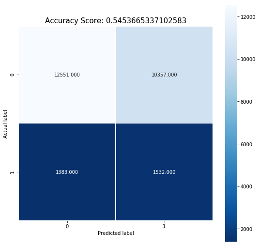

```python
# confusion matrix
cm = metrics.confusion_matrix(y_test, predictions_log)

plt.figure(figsize=(9,9))
sns.heatmap(cm, annot=True, fmt=".3f", linewidths=.5, square = True, cmap = 'Blues_r');
plt.ylabel('Actual label');
plt.xlabel('Predicted label');
all_sample_title = 'Accuracy Score: {0}'.format(score)
plt.title(all_sample_title, size = 15);
```

```python
RF = RandomForestRegressor().fit(x_train, y_train)
```

```python
predictions_RF = RF.predict(x_test)
```

```python
score_RF = RF.score(x_test, y_test)
print(score)
```

```
0.5453665337102583
```